# Lecture 05: Instrumental Variables

EEFE 530

Daniel Brent

# Intro

## Roadmap

### Motivation

- Endogeneity and omitted variable bias
- Simultaneity and measurement error
- Why selection-on-observables may fail

### Instrumental Variables Framework

- Structural vs. reduced form
- Wald estimator (binary instrument)
- 2SLS with multiple instruments

### Identification Assumptions

- Relevance
- Exclusion restriction
- Independence
- Monotonicity (for LATE)

### Interpretation

- LATE and compliers
- Comparison to ATE / ATT
- Policy interpretation

### Implementation in R

- First stage diagnostics
- Weak instrument tests
- Clustered SEs
- `fixest::feols()` IV syntax

### Applications & Pitfalls

- Weak instruments
- Overidentification tests
- Threats to exclusion
- External validity

## Learning Objectives

By the end of this lecture, you should be able to:

- Diagnose sources of endogeneity in an applied setting
- Derive the Wald estimator and interpret 2SLS as a ratio of covariances
- State and evaluate the IV identification assumptions
- Explain LATE and identify the population being estimated
- Implement IV estimation in R and interpret first-stage diagnostics
- Assess instrument strength and common specification threats

## Today

Instrumental variables (and two-stage least squares)

### Upcoming

Difference in Difference

# Reading

## Basics

- MHE Ch. 5
- Mixtape Ch. 9
- Effect Ch. 18

## New DD developments

- de Chaisemartin, D’Haultfoeuille (2022)[Two-Way Fixed Effects and Differences-in-Differences with Heterogeneous Treatment Effects: A Survey](https://academic.oup.com/ectj/advance-article/doi/10.1093/ectj/utac017/6604378)
- Roth, Sant’ Anna, Bilinkski, Poe (2023)[What’s Trending in Differences-in-Differences? A Synthesis of the Recent Econometrics Literature](https://www.sciencedirect.com/science/article/pii/S0304407623001318)
- de Chaisemartin, D’Haultfoeuille (2023)[Difference-in-Differences for Simple and Complex Natural Experiments](https://papers.ssrn.com/sol3/papers.cfm?abstract_id=4487202)
- Baker, Larcker, Wang, (2022)[How Much Should We Trust Staggered Difference-In-Differences Estimates?](https://www.sciencedirect.com/science/article/pii/S0304405X22000204)
- … and papers cited therein

# Research designs

## Selection on observables and/or unobservables

We’ve been focusing on *selection-on-observables* designs, *i.e.*,
$$\begin{align}
\def\ci{\perp\mkern-10mu\perp}
\left(\text{Y}_{0i},\, \text{Y}_{1i}\right) \ci \text{D}_{i}|\text{X}_{i}
\end{align}$$
for **observable** variables $\text{X}_{i}$.

*Selection-on-unobservable* designs replace this assumption with two new (but related) assumptions

1. $\left(\text{Y}_{0i},\, \text{Y}_{1i}\right) \perp \text{Z}_{i}$ - There is a variable $Z_i$ that is independent of the potential outcomes.
2. $\mathop{\text{Cov}} \left( \text{Z}_{i},\, \text{D}_{i} \right) \neq 0$ - That variable $Z_i$ is correlated with treatment $(D_i)$.

## Selection on observables and/or unobservables

The goal of applied econometrics is to estimate causal parameters. We need to isolate exogenous variation in $\text{D}_{i}$.

(We want to avoid selection bias.)

- **Selection-on-observables designs** assume that we can control for all *endogenous variation* (selection) in $\text{D}_{i}$ through a known (and observed) $\text{X}_{i}$.
- **Selection-on-unobservables designs** assume we can isolate *exogenous variation* in $\text{D}_{i}$ (generally using some $\text{Z}_{i}$) and then use this component of $\text{D}_{i}$ to estimate the causal effect of $\text{D}_{i}$ on $\text{Y}_{i}$.

We ignore or remove the *endogenous variation* in $\text{D}_{i}$ (it’s bad).

## Which is better?

Both *selection-on-unobservable* and *selection-on-unobservable* designs represent *identification strategies*. Is one intrinsically prefered to the other?

Both rely on assumptions. The question is which assumptions are defensible in a given application.

1. It’s easy to violate the assumptions of either design.
2. **Selection on observables** assumes we know *everything* about selection into treatment—we can remove all of the selection bias (recall our omitted variable bias formula) Difficult in observational settings, and difficult to validate.
3. **Selection on unobservables** assumes we can isolate *some* exogenous variation in $\text{D}_{i}$, which we then use to estimate the effect of $\text{D}_{i}$ on $\text{Y}_{i}$.  
   Can defend in some settings, and possible to validate. May have power issues.

# Instrumental variables

## Introduction

Note: For the moment, we’re lumping together IV and two-stage least squares (2SLS) together—as many people do—even though they are technically different.

Consider some model (structural equation)
$$\begin{align}
\text{Y}_{i} = \beta_0 + \beta_1 \text{D}_{i} + \varepsilon_i \tag{1}
\end{align}$$
To guarantee consistent (unbiased) OLS estimates for $\beta_1$ we need $\mathop{\text{Cov}} \left( \text{D}_{i},\,\varepsilon_i \right)=0$.

We cannot test this, so really we need to *assume* $\mathop{\text{Cov}} \left( \text{D}_{i},\,\varepsilon_i \right)=0$.  
In general, this is a heroic assumption.

**Alternative:** Estimate $\beta_1$ via instrumental variables.

## Definition

For our model
$$\begin{align}
\text{Y}_{i} = \beta_0 + \beta_1 \text{D}_{i} + \varepsilon_i \tag{1}
\end{align}$$

A valid **instrument** is a variable $\color{#0073e6}{\text{Z}_{i}}$ such that

1. $\mathop{\text{Cov}} \left( \color{#0073e6}{\text{Z}_{i}},\, \text{D}_{i} \right) \neq 0$
- our instrument is correlated with treatment
2. $\mathop{\text{Cov}} \left( \color{#0073e6}{\text{Z}_{i}},\, \varepsilon_i \right) = 0$
- and our instrument is uncorrelated with determinants of $\text{Y}_{i}$ other than $D_i$ **(exclusion restriction)**
- Another way of stating the exclusion restriction is that the only way that $Z_i$ affects $Y_i$ is through $D_i$.

## Example

Back to the returns to a college degree,
$$\begin{align}
\text{Income}_i = \beta_0 + \beta_1 \text{Grad}_i + \varepsilon_i
\end{align}$$
OLS is likely biased.

Why?

What if that state conducts a random **lottery** for scholarships?

Let $\color{#0073e6}{\text{Lottery}_i}$ denote an indicator for whether $i$ won a lottery scholarship.

Note: It’s important to consider who is eligible and/or applied to the lottery.

1. $\mathop{\text{Cov}} \left( \color{#0073e6}{\text{Lottery}_i},\, \text{Grad}_i \right)\neq 0$ if scholarships increase graduation rates.
2. $\mathop{\text{Cov}} \left(\color{#0073e6}{\text{Lottery}_i},\, \varepsilon_i\right) = 0$ since the lottery is randomized.

# Instrumental variables

## The IV estimator

The IV estimator for our model
$$\begin{align}
\text{Y}_{i} = \beta_0 + \beta_1 \text{D}_{i} + \varepsilon_i \tag{1}
\end{align}$$
with (valid) instrument $\color{#0073e6}{\text{Z}_{i}}$ is
$$\begin{align}
\hat{\beta}_\text{IV} = \left(\text{Z}'\text{D}\right)^{-1} \left( \text{Z}'\text{Y}\right)
\end{align}$$

If you have no covariates, then
$$\begin{align}
\hat{\beta}_\text{IV} = \dfrac{\mathop{\text{Cov}} \left( \color{#0073e6}{\text{Z}_{i}},\, \text{Y}_{i}\right)}{\mathop{\text{Cov}} \left( \color{#0073e6}{\text{Z}_{i}},\, \text{D}_{i} \right)}
\end{align}$$

If you have additional (exogenous) covariates $\text{X}_i$, then
$$\begin{align}
\text{Z} &= \begin{bmatrix}\color{#0073e6}{\text{Z}_{i}} & \text{X}_{i}\end{bmatrix}
\\[0.5em]
\text{D} &= \begin{bmatrix}\color{#0073e6}{\text{D}_{i}} & \text{X}_{i}\end{bmatrix}
\end{align}$$

# Two-stage least squares

## Setup

We often implement IV as a two-stage process known as **two-stage least squares** (2SLS).

**First stage:** Estimate the effect of the instrument $\color{#0073e6}{\text{Z}_{i}}$ on our endogenous treatment variable $\text{D}_{i}$ and (predetermined) covariates $\text{X}_{i}$. Save $\color{#006400}{\widehat{\text{D}}_{i}}$.

$$\begin{align}
\text{D}_{i} = \gamma_1 \color{#0073e6}{\text{Z}_{i}} + \gamma_2 \text{X}_{i} + u_i
\end{align}$$

**Second stage:** Estimate the original structural model replace $\text{D}_i$ with $\color{#006400}{\widehat{\text{D}}_{i}}$.

$$\begin{align}
\text{Y}_{i} = \beta_1 \color{#006400}{\widehat{\text{D}}_{i}} + \beta_2 \text{X}_{i} + \varepsilon_i
\end{align}$$

**Note:** The controls $\text{X}_{i}$ must match in the first and second stages.

## IV estimation

This two-step procedure, with a valid instrument, produces an estimator $\hat{\beta}_1$ that is consistent for $\beta_1$.

$$\begin{align}
\hat{\beta}_\text{2SLS} &= \left( \text{D}' \text{P}_{\text{Z}} \text{D} \right)^{-1} \left( \text{D}' \text{P}_{\text{Z}} \text{Y} \right)
\\[0.3em]
\text{P}_{\text{Z}} &= \text{Z} \left( \text{Z}'\text{Z} \right)^{-1} \text{Z}'
\end{align}$$

where $\text{D}$ is a matrix of our treatment and predetermined covariates $\left( \text{X}_{i} \right)$ and $\text{Z}$ is a matrix of our instrument and our predetermined covariates.

## IV estimation

Important notes

- The controls $\left( \text{X}_{i} \right)$ must match in the first and second stages.
- If you have exactly **one instrument** and exactly **one endogenous variable**, then 2SLS and IV are identical.
- Your second-stage standard errors are not correct.

## The reduced form

In addition to the regressions within the two stages of 2SLS

1. $\text{D}_{i} = \gamma_1 \color{#0073e6}{\text{Z}_{i}} + \gamma_2 \text{X}_{i} + u_i$
2. $\text{Y}_{i} = \beta_1 \color{#006400}{\widehat{\text{D}}_{i}} + \beta_2 \text{X}_{i} + \varepsilon_i$

there is a third important and related regression:

the reduced form.

The **reduced form** regresses the outcome $\text{Y}_{i}$ (LHS of the second stage) on our instrument $\color{#0073e6}{\text{Z}_{i}}$ and covariates $\text{X}_{i}$ (RHS of the first stage).
$$\begin{align}
\text{Y}_{i} = \pi_1 \color{#0073e6}{\text{Z}_{i}} + \pi_2 \text{X}_{i} + u_i
\end{align}$$

Thus, the reduced form provides a consistent estimate of the causal effect of our instrument on the outcome.

## The reduced form

While the reduced form estimates the causal effect of the instrument on our outcome, we’re usually interested in the effect of *treatment* $\left( \text{D}_{i} \right)$.

That said, the reduced form is still incredibly helpful/important:

- Clarifies your source of identifying variation.
- Does not suffer from *weak instruments* problems.
- Only requires $\mathop{\text{Cov}} \left( \text{Z}_{i},\, \varepsilon_i \right) = 0$.
- Offers insights into your estimates

$$\begin{align}
\widehat{\beta}_{1}^\text{2SLS} = \dfrac{\widehat{\pi}_{1}}{\widehat{\gamma}_{1}}
\end{align}$$
when you have exactly one instrument.

## The reduced form, intuition

This expression for the 2SLS (and IV) estimator can be very helpful.
$$\begin{align}
\widehat{\beta}_{1}^\text{2SLS} = \dfrac{\color{#8B0000}{\widehat{\pi}_{1}}}{\color{#006400}{\widehat{\gamma}_{1}}} = \dfrac{\color{#8B0000}{\text{Reduced-form estimate}}}{\color{#006400}{\text{First-stage estimate}}}
\end{align}$$

What’s the interpretation/intuition?

Back to our example: $\widehat{\beta}_1 =$ estimated effect of college graduation on income.

$\color{#8B0000}{\widehat{\pi}_1}$ gives the estimated causal effect of the scholarship lottery on income.

We need to consider how winning the lottery affects graduation. We need to rescale $\color{#8B0000}{\widehat{\pi}_1}$ if the effect of lottery on graduation is $<$ 100%.

$\color{#006400}{\widehat{\gamma}_1}$ estimates the effect of winning the scholarship lottery on graduation — the share of winners who graduated *due* to winning.

We can scale with $\color{#006400}{\widehat{\gamma}_1}$!

## The reduced form, example

Let’s gain some insight into scaling the reduced form. Imagine that 50% of lottery winners graduate from college due to the lottery, *i.e.*, $\color{#006400}{\widehat{\gamma}_1 =}$ 0.50.

Imagine none of the applicants would have graduated otherwise

Our reduced-form estimate of $\color{#8B0000}{\widehat{\pi}_1= \$5,000}$ says that lottery winners make $5,000 more than the control group, on average.

However, half of the winners did not graduate, so $\color{#8B0000}{\widehat{\pi}_1}$ “underestimates” the effect of college graduation by combining graduates by nongraduates.

Thus, we want to double $\color{#8B0000}{\widehat{\pi}_1}$, *i.e.*, divide by $\color{#006400}{\widehat{\gamma}_1}$:

$\color{#8B0000}{\widehat{\pi}_1}/\color{#006400}{\widehat{\gamma}_1}$ =$\color{#8B0000}{\$5,000}/\color{#006400}{0.50}$ = $10,000.

**Q:** How do we get this intuitive expression? $\left( \widehat{\beta}_1^\text{IV} = \dfrac{\widehat{\pi}_1}{\widehat{\gamma}_1} \right)$

## Derivation

$\widehat{\beta}_1^\text{IV} = \left( \text{Z}'\text{D} \right)^{-1} \left( \text{Z}'\text{Y} \right)$

$\color{#ffffff}{\widehat{\beta}_1^\text{IV}} = \left( \widetilde{\text{Z}}'\widetilde{\text{D}} \right)^{-1} \left( \widetilde{\text{Z}}'\text{Y} \right)$ applying FWL to reduce $\text{D}$ and $\text{Z}$ to vectors.

$\color{#ffffff}{\widehat{\beta}_1^\text{IV}} = \dfrac{\mathop{\text{Cov}} \left( \widetilde{\text{Z}}_{i},\, \text{Y}_{i} \right)}{\mathop{\text{Cov}} \left( \widetilde{\text{Z}}_i,\, \widetilde{\text{D}}_{i} \right)}$

$= \dfrac{\mathop{\text{Cov}} \left( \widetilde{\text{Z}}_{i},\, \text{Y}_{i} \right)/\mathop{\text{Var}} \left( \widetilde{\text{Z}}_i \right)}{\mathop{\text{Cov}} \left( \widetilde{\text{Z}}_i,\, \widetilde{\text{D}}_{i} \right)/\mathop{\text{Var}} \left( \widetilde{\text{Z}}_i \right)}$

$\color{#ffffff}{\widehat{\beta}_1^\text{IV}} = \dfrac{\widehat{\pi}_1}{\widehat{\gamma}_1}$ ✔

Let’s push a bit deeper into IV’s mechanics and intuition.

# IV: Mechanics and intuition

## Setup

In this section, we’ll use medical trials as a working example.

We are interested in the regression model for the effect of some treatment (*e.g.*, blood-pressure medication) on medical outcome $\text{Y}_{i}$

$$\begin{align}
\text{Y}_{i} = \beta_0 + \beta_1 \text{D}_{i} + \varepsilon_i
\end{align}$$
$\text{D}_{i}$ indicates whether $i$ *takes* the treatment (medication). $\varepsilon_i$ captures all other factors that affect $\text{Y}_{i}$.

Or in potential-outcomes framework:

$$\begin{align}
\text{Y}_{i} &= \text{Y}_{1i} \text{D}_{i} + \text{Y}_{0i} (1-\text{D}_{i}) \\
\text{Y}_{0i} &= \beta_0 + \varepsilon_i \\
\text{Y}_{1i} &= \text{Y}_{0i} + \beta_1
\end{align}$$

Credit/thanks go to [Michael Anderson](https://are.berkeley.edu/~mlanderson/ARE_Website/Home.html) via [Ed Rubin](http://edrub.in/) for this example—and much of these notes.

## Research design

**Goal:** *Estimate the effect of blood-pressure medication* on blood pressure.

**Challenge:** *Selection bias:* Even if treatment reduces blood pressure, selection bias fights against the estimated effect.

**Solution:** *Randomized medical trial:* Ask randomly chosen individuals in treatment group to take the pill. Control individual get placebo (or nothing).

**Analysis 1:** *Intention to treat (ITT)*: $\widehat{\beta}_1^\text{ITT} = \overline{\text{Y}}_\text{Trt} - \overline{\text{Y}}_\text{Ctrl}$

**ITT problem:** *Bias from noncompliance:* People don’t always follow rules.  
*E.g.*, treated folks who don’t take pills; control folks who take pills.

**Analysis 2:** *IV!*

Instrument medication $\text{D}_{i}$ with intention to treat $\text{Z}_{i}$.

## The IV solution

First question: Is $\text{Z}_{i}$ a valid instrument for $\text{D}_{i}$?

1. $\mathop{\text{Cov}} \left( \text{Z}_{i},\, \varepsilon_i \right) = 0$ as $\text{Z}_{i}$ was randomly assigned (exclusion restriction).
2. $\mathop{\text{Cov}} \left( \text{Z}_{i},\, \text{D}_{i} \right)\neq 0$ if assignment to treatment changes the likelihood you take the pills (first stage).

∴ $\text{Z}_{i}$ is a valid instrument for $\text{D}_{i}$ and IV consistently estimates $\beta_1$.

## Noncompliance

**Noncompliant** individuals do not abide by their treatment assignment.

Let’s see how IV “solves” this problems.

First, assume noncompliance only affects treated individuals—*i.e.*, treated folks sometimes don’t take their pills; control folks never take pills.

This is often called one-sided noncompliance. This would be the case of the COVID vaccine trials where the vaccine is not publicly available so subjects in the control group **cannot** take get the shot.

## Noncompliance, continued

The **first stage** recovers the share of treatment individuals who take the pill
$$\begin{align}
\text{D}_{i} = \gamma_1 \text{Z}_{i} + u_i
\end{align}$$

*i.e.*, if 50% of treated individuals take the medication, $\widehat{\gamma} =$ 0.50.

The **reduced form** estimates the *ITT*
$$\begin{align}
\text{Y}_{i} = \pi_1 \text{Z}_{i} + v_i
\end{align}$$

which we know IV rescales using the first stage
$$\begin{align}
\widehat{\beta}_{1}^\text{IV} = \dfrac{\widehat{\pi}_1}{\widehat{\gamma}_1} = \dfrac{\widehat{\pi}_1}{0.50} =
2 \times \widehat{\pi}_1
\end{align}$$

## Noncompliance, continued

IV solves the noncompliance issue by rescaling by the rate of compliance.

If everyone perfectly complies, then $\widehat{\gamma}_1 = 1$ and $\widehat{\beta}_{1}^\text{IV} = \widehat{\pi}_1/1 = \widehat{\beta}_{1}^\text{ITT}$.

**Further example:** $N_\text{Trt}$ = 10; trt. compliance = 50%; ctrl. compliance = 100%.

$\overline{\text{Y}}_\text{Trt} = \dfrac{5 (\beta_0 + \beta_1) + 5 (\beta_0)}{10} = \beta_0 + \dfrac{\beta_1}{2}$

and $\overline{\text{Y}}_\text{Ctrl} = \beta_0$.

So our reduced-form estimate (the ITT) is $\widehat{\gamma}_1 = \dfrac{\beta_1}{2}$ (half the true effect).

IV consistently estimates $\beta_1$ via rescaling the ITT by the rate of compliance
$$\begin{align}
\widehat{\beta}_1^\text{IV} = \dfrac{\pi}{\gamma} = \dfrac{\beta_1/2}{1/2} = \beta_1
\end{align}$$

## Example

This can have big implications in many settings including medical trials with imperfect compliance.

Doctors and public health officials advocate for cancer screening as cost-effective medical intervention.

However, randomized trials for that invite participants to free colonoscopy and sigmoidoscopy show very different results.

So do screenings work?

Enter IV!

[Angrist and Hull (2023)](https://www.pnas.org/doi/10.1073/pnas.2311556120)

## Example

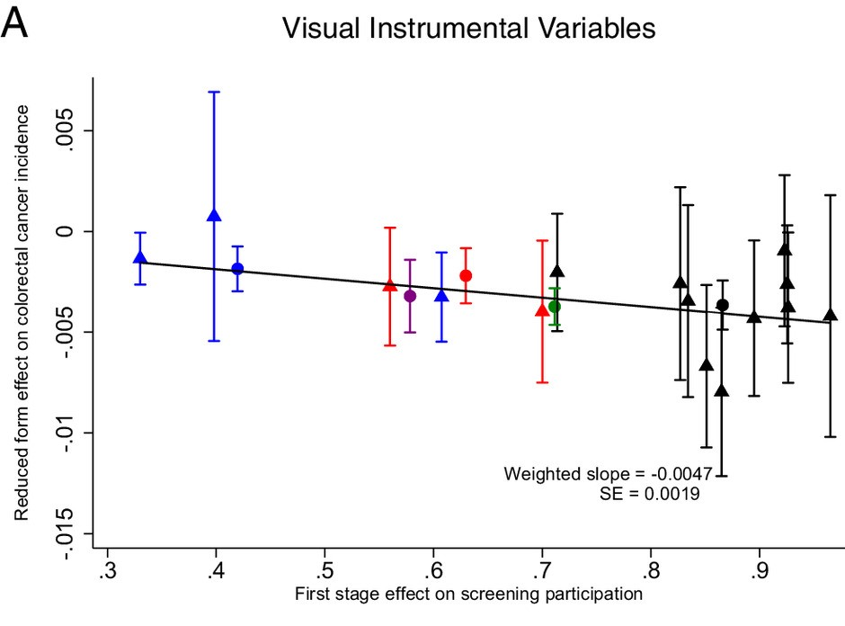

## Example

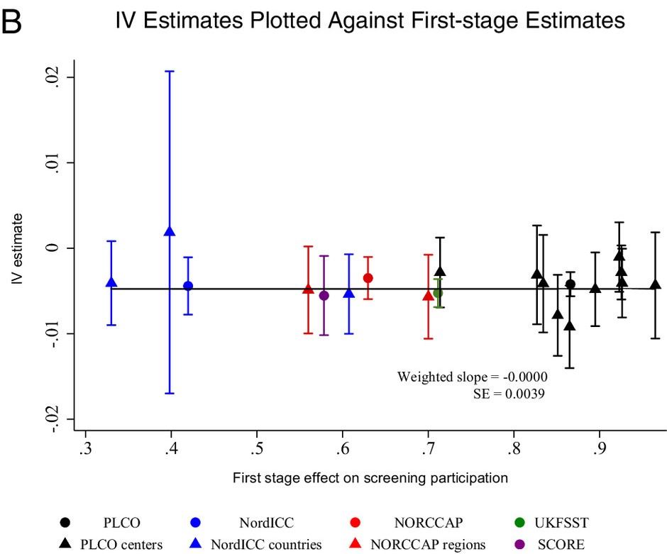

## Takeaways

Main points

1. IV **rescales** the causal effect of $\color{#0073e6}{\text{Z}_{i}}$ on $\color{#0073e6}{\text{Y}_{i}}$ by the causal effect of $\color{#006400}{\text{Z}_{i}}$ on $\color{#006400}{\text{D}_{i}}$.
2. IV **does not** compare treated compliers to untreated non-compliers.

Such a comparison/estimator would re-introduce selection bias.

Thus far, we assumed homogeneous treatment effects.

**Q:** What happens *when treatment effects are heterogeneous*?

# IV + heterogeneity

## Recap

So far we’ve discussed two concepts of treatment effects (really 3 if you count ITT).

1. **Average treatment effect (ATE):** The average treatment effect for an individual randomly drawn from our sample.
2. **Average Treatment effect on the treated (ATT):** The average treatment effect for a *treated* individual randomly drawn from our sample.

When we assume homogeneous/constant treatment effects, ATE = ATT

**Q:** If treatment effects vary, then what do IV and 2SLS estimate?

**A:** Not ATE.

And not ATT.

They estimate the LATE.

See [Angrist, Imbens, and Rubin (1996)](https://www.jstor.org/stable/2291629).

## The LATE

IV generally estimates the **LATE** — the Local Average Treatment Effect.

**Recall:** IV works by isolating variation in $\text{D}_{i}$ induced by our instrument $\text{Z}_{i}$.

In other words: IV focuses on the individuals whose $\text{D}_{i}$ changes **due** to $\text{Z}_{i}$.

Angrist, Imbens, and Rubin (1996) call these individuals **compliers**.

However, *compliers* are only one of four possible groups.

1. **Compliers** $\text{D}_{i} = 1$ iff $\text{Z}_{i}=1$.
2. **Always-takers** $\text{D}_{i} = 1$ $\forall \text{ Z}_{i}$.
3. **Never-takers** $\text{D}_{i} = 0$ $\forall \text{ Z}_{i}$.
4. **Defiers** $\text{D}_{i} = 1$ iff $\text{Z}_{i}=0$.
1. **Compliers** Only take pills **when treated**.
2. **Always-takers** **Always** take pills.
3. **Never-takers** **Never** take pills.
4. **Defiers**  
   Only take pills **when untreated**.

## The LATE

Because IV only uses variation in $\text{D}_{i}$ that correlates with $\text{Z}_{i}$, IV mechanically drops *always-takers* and *never-takers*.

Most IV derivations/applications assume away the existence of *defiers*.

*What’s the problem with defiers and what assumption does IV usually make to deal with them?*

We’ll come back to this later.

Thus, IV estimates a treatment effect **using only *compliers***.

Hence the “local” in *local average treatment effect*.

We can only make inference on a subset of the population of interest - **those who are induced into treatment by the instrument.**

## The LATE: Medical-trial example

Imagine treatment works for some $\left( \beta_{1,i} < 0 \right)$ and not for others $\left( \beta_{1,j} = 0 \right)$.

Suppose individuals know their response to blood-pressure medication.

- $\beta_{1,i}<0$ individuals always take the pill.
- $\beta_{1,j}=0$ individuals only take the pill when treated.

Then our compliers will be individuals for whom $\beta_{1,j}=0$.

Thus, IV’s LATE will indicate no treatment effect $\left( \widehat{\beta}_1^\text{IV} = 0 \right)$ even though the true ATE is nonzero $\left( \beta_1^\text{ATE} \neq 0 \right)$ .

## The LATE

**Q:** So is IV actually inconsistent?

**A:** It depends what you are trying to estimate (and how you interpret it).

IV doesn’t estimate the ATE or ATT, so it would be inconsistent for them.

IV estimates the *local* average treatment effect.

**Takeaway 1:** Because IV identifies off of compliers, it estimates an average treatment effect for these individuals (who *comply* with the instrument).

**Takeaway 2:** Different instruments have different LATEs.

## Monotonicity

We’ve already written down the two classical IV/2SLS assumptions

- **First stage:** $\mathop{\text{Cov}} \left( \text{Z}_{i},\, \text{D}_{i} \right) > 0$
- **Exclusion restriction:** $\mathop{\text{Cov}} \left( \text{Z}_{i},\, \varepsilon_{i} \right) = 0$

but we need a third assumption to ensure IV’s complier-based LATE interpretation.

- **Monotonicity (Uniformity):** $\text{D}_{i}(z)\geq \text{D}_{i}(z')$ or $\text{D}_{i}(z)\leq \text{D}_{i}(z') \enspace \forall i$
  - [Heckman](http://jenni.uchicago.edu/papers/koop2006/koop2-IV_ho_2006-09-25a_mms.pdf): *Uniformity* of responses *across persons.*
  - [Imbens and Angrist (1994)](https://www.jstor.org/stable/2951620): Instrument has monotone effect on $\text{D}_{i}$.

## Monotonicity

If “defiers” exist, then monotonicity/uniformity is violated.

In this case, the IV estimand is

$$\begin{align}
\dfrac{\tau_{c} \mathop{\text{Pr}}\left(\text{complier}\right) - \tau_{d} \mathop{\text{Pr}}\left(\text{defier}\right)}{ \mathop{\text{Pr}}\left(\text{complier}\right) - \mathop{\text{Pr}}\left(\text{defier}\right)}
\end{align}$$

which is not bound between $\tau_{c}$ and $\tau_{d}$.

**Example:** $\tau_c=$ 1 and $\tau_d=$ 2. $\mathop{\text{Pr}}\left(\text{complier}\right)=$ 2/3 and $\mathop{\text{Pr}}\left(\text{defier}\right)=$ 1/3.

Then the “LATE” is 0.

**Note:** Some people would instead say that there is no LATE when you violate monotonicity.

Until now, we’ve focused on using a single instrument.

The 2SLS estimator accommodates multiple instruments.

Whether you can find multiple valid instruments is another question.

# Multiple instruments

## Motivation

**Q:** Why include multiple instruments?

**A:** Multiple instruments can capture more variation in $\text{D}_{i}$ (efficiency).

Using terminology from the *system-of-equations* literature,

- one instrument for one endogenous variable: *just identified*
- multiple instruments for one endogenous variable: *over identified*

## In practice

With (valid) instruments $\text{Z}_{1i}$ and $\text{Z}_{2i}$, the first stage becomes
$$\begin{align}
\text{D}_{i} = \gamma_0 + \gamma_1 \text{Z}_{1i} + \gamma_2 \text{Z}_{2i} + \gamma_3 \text{X}_{i} + u_i
\end{align}$$

while the second stage is still
$$\begin{align}
\text{Y}_{i} = \beta_0 + \beta_1 \widehat{\text{D}}_{i} + \beta_2 \text{X}_{i} + v_i
\end{align}$$

# Weak Instruments

## Weak instruments and the first stage

Recall how the first stage estimate affects the 2SLS estimate.
$$\begin{align}
\widehat{\beta}^\text{2SLS} = \dfrac{\widehat{\pi}}{\widehat{\gamma}}
\end{align}$$
where $\widehat{\pi}$ is the reduced form estimate and $\widehat{\gamma}$ is the first stage estimate.

$\widehat{\gamma}$ enters this formula in the **denominator** and therefore has a **nonlinear** effect on $\widehat{\beta}^\text{2SLS}$

When $\gamma$ is small then small variation in $\widehat{\gamma}$ can have really big impacts on $\widehat{\beta}^\text{2SLS}$.

Let’s look at this with some simulations

**Note:** Acknowledgement to Paul Goldsmith-Pinkham for these simulations.

2SLS simulation:

- binary instrument
- First stage coefficient = 0.5
- $\beta$ = 2
- Variation in 2SLS estimation comes from variation in first stage
- In this setting the length of the interval corresponds to the variation/strength of the instrument

[figure not shown]

First stage coefficient = 0.5; $\beta$ = 2

[figure not shown]

First stage coefficient = 0.1; $\beta$ = 2

[figure not shown]

Variation to estimate true effect is tiny.

[figure not shown]

First stage coefficient = 0.01; $\beta$ = 2

Let’s look at how this impacts the 2SLS estimates.

The first stage estimates look okay

[figure not shown]

However, the problems show up looking at the relationship between $\widehat{\gamma}$ and $\widehat{\beta}$.

This relationship is nonlinear and undefined when $\widehat{\gamma}$ = 0.

[figure not shown]

If the first stage is small and marginally significant (estimate = 0.1, se = 0.05) then a researcher may proceed with the analysis.

However, the distribution for $\widehat{\beta}$ is non normal, and asymptotic normality is a bad approximation.

[figure not shown]

This is not the case if the first stage is larger in magnitude (0.5).

[figure not shown]

## Solutions to weak instruments: Pretesting

- One solution is to test whether the first stage relationship is “strong”
- A common approach is to look at the F-statistic
- [Staiger and Stock (1997)](https://www.jstor.org/stable/2171753) and [Stock and Yogo (2002)](https://www.nber.org/papers/t0284) develop a rule of thumb of an F-stat above 10
- Bias won’t be larger than 10% with size of 5%
- Key assumption is homoskedasticity

## Solutions to weak instruments: Pretesting

- Montieal and Pflueger (2013) have a heteroskedasticity-robust test
  - cutoff is closer to 23
- [Lee et al. (2022)](https://www.aeaweb.org/articles?id=10.1257/aer.20211063) show that current practice focuses on the $\beta$ term as opposed to the t-statistic
- Need a stronger F-stat of over 100!!

## Solutions to weak instruments: Pretesting

- [Angrist & Kolesar (2023)](https://www.sciencedirect.com/science/article/pii/S0304407623000295) claim that weak instruments are not a major concern in the just identified case
- Endogeneity needs to **very** high for the bias to outweigh the increase in noise.
- When endogeneity is less that 0.76, CI are distorted by no more than 5% for any F-stat.
- Focus on screening on the *sign* of the first stage as opposed to the F-stat

# 2SLS and R

## `estimatr`

You can implement 2SLS/IV in many ways in R. We’ll use `estimatr` and `iv_robust()`.

First let’s create some sample data.

```r
# Set seed
set.seed(12345)
# Sample size
n <- 100
# Define our variance-covariance matrix (D, ε, Z)
sig <- matrix(data = c(1, 0.5, 0.5, 0.5, 1, 0, 0.5, 0, 1), ncol = 3)
# Our vector of means (D, ε, Z)
mu = c(10, 0, 3)
# Draw n observations; convert to tibble
sample_data <- as.data.table(mvrnorm(n = n, mu = mu, Sigma = sig))
# Name variables
names(sample_data) <- c("D", "e", "Z")
# Calculate Y
sample_data[,Y := 7 + 2 * D + e]
```

Specifically, we give `iv_robust()` the relationship that we want separted from the instrument by `|`

, *e.g.*,

```r
# Estimate 2SLS
twosls <- iv_robust(Y ~ D | Z, data = sample_data, se_type = "classical")
tidy(twosls)[1:5]
```

```
#>          term estimate std.error statistic      p.value
#> 1 (Intercept) 5.637525 1.8003223  3.131398 2.293598e-03
#> 2           D 2.121242 0.1842559 11.512480 6.577085e-20
```

## Now in two stages!

We can also estimate 2SLS in two stages.

```r
# First stage
stage1 <- lm_robust(D ~ Z, data = sample_data, se_type = "classical")
# First-stage results
tidy(stage1)[1:5]
```

```
#>          term  estimate  std.error statistic      p.value
#> 1 (Intercept) 8.2078914 0.29282475 28.030047 1.354379e-48
#> 2           Z 0.5366599 0.09583812  5.599649 1.962503e-07
```

## Second stage

We just need to add $\widehat{\text{D}}_{i}$ to our dataset, and regress Y on $\widehat{\text{D}}_{i}$.

```r
# Add fitted (first-stage) values to data
sample_data[,D_hat := stage1$fitted.values]
# Second stage
stage2 <- lm_robust(Y ~ D_hat, data = sample_data, se_type = "classical")
# Second-stage results
tidy(stage2)[1:5]
```

```
#>          term estimate std.error statistic      p.value
#> 1 (Intercept) 5.637525 5.0620048  1.113694 2.681345e-01
#> 2       D_hat 2.121242 0.5180762  4.094460 8.707982e-05
```

## LATE

We could also calculate the LATE ‘by hand’.

Recall that:
$$\begin{align}
\widehat{\beta}^\text{IV} = \dfrac{\widehat{\pi}}{\widehat{\gamma}}
\end{align}$$
where $\widehat{\pi}$ is the reduced form estimate and $\widehat{\gamma}$ is the first stage estimate.

Let’s first estimate the reduced form (ITT).

```r
# First stage
reduce <- lm_robust(Y ~ Z, data = sample_data, se_type = "classical")
# First-stage results
tidy(reduce)[1:5]
```

```
#>          term  estimate std.error statistic      p.value
#> 1 (Intercept) 23.048450 0.8494977  27.13186 2.297274e-47
#> 2           Z  1.138386 0.2780307   4.09446 8.707982e-05
```

## LATE

From `reduce` $\widehat{\pi}$ =

```r
coef(reduce)[2]
```

```
#>        Z
#> 1.138386
```

and from `stage1` $\widehat{\gamma}$ =

```r
coef(stage1)[2]
```

```
#>         Z
#> 0.5366599
```

$$\begin{align}
\widehat{\beta}^\text{IV} = \dfrac{\widehat{\pi}}{\widehat{\gamma}} = \dfrac{1.138}{0.537} = 2.121
\end{align}$$

## Standard errors

However, recall that our second-stage standard errors are not correct.

Second-stage results

```
#>          term estimate std.error statistic      p.value
#> 1 (Intercept) 5.637525 5.0620048  1.113694 2.681345e-01
#> 2       D_hat 2.121242 0.5180762  4.094460 8.707982e-05
```

**2SLS results**

```
#>          term estimate std.error statistic      p.value
#> 1 (Intercept) 5.637525 1.8003223  3.131398 2.293598e-03
#> 2           D 2.121242 0.1842559 11.512480 6.577085e-20
```

# IV and 2SLS

## Conclusions

1. IV/2SLS focus on **isolating some exogenous variation** in $\text{D}_{i}$ via $\text{Z}_{i}$.
2. Important **requirements**: strong first stage, excludability, monotonicity.
3. IV and 2SLS **rescale the reduced form** with the first stage.
4. Estimates are **LATE from compliers**.
5. Different instruments can produce **different LATEs**.
6. A **weak first stage** can lead to problems.